# RenertPY - collection of functions used to teach Python at Renert School

List-related functions:

- `bar_plot(list [,color-name])`
- `line_plot(list [,color-name])`
- `greyscale_plot(list [,color-name])`
- `greyscale_2d_plot(list, width, [,color-name])`
- `colorname_plot(list)`
- `rgb_plot(list-of-lists)`

To simplify teaching:

```python
from renertpy.all import *
```

# Bar Plot - `bar_plot(list [,color])`

accepts values from 0 to 100 , and optional color name:

```python
data = [10,50,60,100,90,90,90,0,0,100,100,100]
bar_plot(data)
```

[output not shown]

```python
bar_plot(data,"purple")
```

[output not shown]

# Line Plot - `line_plot( list [,color])`

accepts values from -100 to 100, and optional color:

```python
data = [10,50,60,100,90,90,90,-80,-20,100,100,100]
line_plot(data)
```

[output not shown]

# Greyscale plot - `greyscale_plot(list [,color])`

accepts values from 0 (black) to 255 (white or color), always plots a 1D (linear) color rectangles:

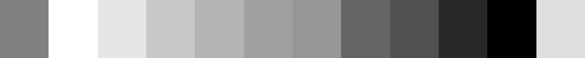

```python
data = [128,255,230,200,180,160,150,100,80,40,0,222]
greyscale_plot(data)
```

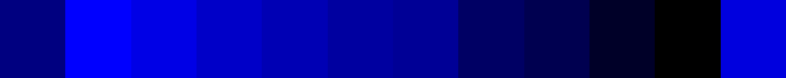

```python
greyscale_plot(data,"blue")
```

# 2D greyscale plot - `greyscale_2d_plot(list, width [,color])`

accepts a 1D list of values (0 to 255) and a desired width. \ Height is calculated automatically (size of list divided by width). \ plots the list as a 2D image. \ Same 1D list can be plotted in multiple width to illustrate the concept. \ Color optional (defaults to white).

```python
data = [ 255, 80,  110, 130,
         20,  200, 100, 110,
         30,  150, 230, 150 ]
greyscale_2d_plot(data,4,"pink")
```

[output not shown]

```python
greyscale_2d_plot(data,2,"pink")
```

[output not shown]

```python
greyscale_2d_plot(data,6,"pink")
```

[output not shown]

# Color-name plot - `colorname_plot(list)`

accepts a list of strings, each string must be a valid color name. See [HTML4/CSS1 Colors](https://www.w3.org/TR/css-color-4/#named-colors) for the complete list.

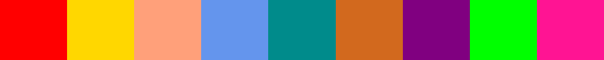

```python
data = [ "red","gold","lightsalmon","cornflowerblue","darkcyan","chocolate", "purple", "lime","deeppink"]
colorname_plot(data)
```

# RGB Plot - `rgb_plot( list-of-list )`

Accepts a **2D** list of triple RGB values (each from 0 to 255). \ Always plots a 1D (linear) rectangles of colors.

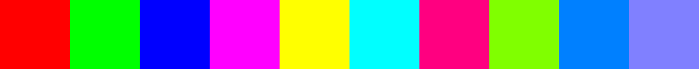

```python
data3 = [
         [255,0,0],
         [0,255,0],
         [0,0,255],

         [255,0,255],
         [255,255,0],
         [0,255,255],

         [255,0,128],
         [128,255,0],
         [0,128,255],

         [128,128,255],
       ]

rgb_plot(data3)
```

# Example - Random data for Bar-Plot

```python
from random import randint


data = [randint(0,100) for x in range(60)]
bar_plot(data, color="blue")
```

[output not shown]

# Example - Random data for 2D greyscale plot

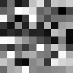

```python
from random import randint
data = [randint(0,255) for x in range(100)]
greyscale_2d_plot(data,10)
```

```python
greyscale_2d_plot(data,20)
```

[output not shown]

# Example - Random Color names

```python
import PIL
all_color_names = list(PIL.ImageColor.colormap)
all_color_names[:10]  # show first 10 colors
```

```
['aliceblue',
 'antiquewhite',
 'aqua',
 'aquamarine',
 'azure',
 'beige',
 'bisque',
 'black',
 'blanchedalmond',
 'blue']
```

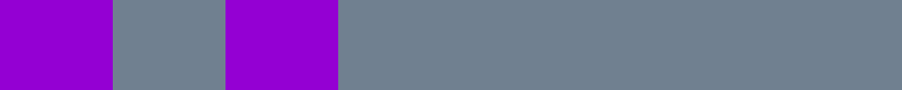

```python
import random

c1 = random.choice(all_color_names)
c2 = random.choice(all_color_names)
data = [ c1, c2, c1, c2, c2, c2, c2, c2  ]
colorname_plot(data)
```

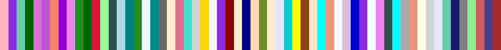

```python
data = [  random.choice(all_color_names) for x in range(60) ]
colorname_plot(data)
```

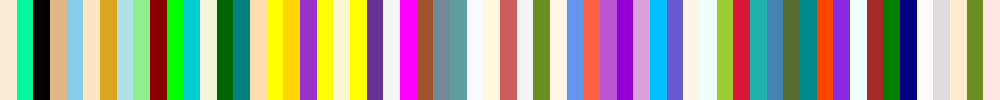

```python
data = random.choices(all_color_names, k = 60)
colorname_plot(data)
```